# G2PML: tutorial on basic usage of the tool

Juan A. Botía

25/04/2019

# Introduction

G2PML is set of datasets and software to study monogenic diseases. We study the diseases through the genes already discovered to be associated to the disease in the Mendelian way (i.e. one mutation, one case). These genes form what is known as a panel of genes.

Our approach to the disease is by describing genes in terms of (a) genetic constraint related properties, (b) genomic related properties and (c) transcriptomics.

With G2PML and your panel P={g1,g2,…,gn} of choice, where gi is the i-th gene, you can

- Perform an analysis on which features are relevant to distinguish those genes from the rest
- Create prediction models to predict new genes from the set of P genes and annotate and score the predictions.
- Enlarge your DDBB of properties to incorporate new ones to enrich your analysis

In our studies, we have been using the PanelApp database of gene panels, from Genomics England, accesible at http://panelapp.genomicsengland.co.uk. In the package we incorporta functions to navigate the panels and access the genes. For example, in

```r
library(G2PML)
panels = getPanelsFromPanelApp()
names(panels)
```

```
##  [1] "Name"               "Number_of_Regions"  "CurrentCreated"
##  [4] "Status"             "Number_of_STRs"     "Relevant_disorders"
##  [7] "CurrentVersion"     "DiseaseSubGroup"    "DiseaseGroup"
## [10] "Panel_Id"           "Number_of_Genes"    "PanelTypes"
```

```r
dim(panels)
```

```
## [1] 173  12
```

```r
panels$Name[1:10]
```

```
##  [1] "Adult solid tumours for rare disease"
##  [2] "Amelogenesis imperfecta"
##  [3] "Amyotrophic lateral sclerosis/motor neuron disease"
##  [4] "Anophthalmia or microphthalmia"
##  [5] "Arrhythmogenic cardiomyopathy"
##  [6] "Arthrogryposis"
##  [7] "Atypical haemolytic uraemic syndrome"
##  [8] "Auditory Neuropathy Spectrum Disorder"
##  [9] "Autosomal recessive congenital ichthyosis"
## [10] "Beckwith-Wiedemann syndrome (BWS) and other congenital overgrowth disorders"
```

We can access 173 gene panels and their genes. For example, we can get the genes for monogenic forms of PD as follows

```r
genes = getGenesFromPanelApp (disorder="Neurology and neurodevelopmental disorders",
                     panel="Parkinson Disease and Complex Parkinsonism",
                     color="green")
genes
```

```
##  [1] "PRKN"     "ATP13A2"  "ATP1A3"   "C19orf12" "CSF1R"    "DCTN1"
##  [7] "DNAJC6"   "FBXO7"    "FTL"      "GBA"      "GCH1"     "GRN"
## [13] "LRRK2"    "LYST"     "MAPT"     "OPA3"     "PANK2"    "PARK7"
## [19] "PINK1"    "PLA2G6"   "PRKRA"    "RAB39B"   "SLC30A10" "SLC39A14"
## [25] "SLC6A3"   "SNCA"     "SPG11"    "SPR"      "SYNJ1"    "TH"
## [31] "TUBB4A"   "VPS13A"   "VPS35"    "WDR45"
```

We’ll take those genes as an example on how to use GP2ML to study the phenotype.

# Relevant features on your gene panel

At this point, we have ready our gene list to study. And we want to know what makes it different this list of genes from the rest of genes in the genome (note we only consider for now protein coding genes as many of the features we use to desdribe them just only make sense for that gene biotype).

Note that we have many different properties to describe our genes. To quickly get a hint on how these genes are described, we can do

```r
genedata = G2PML::fromGenes2MLData(genes=genes,which.controls="allgenome")
```

```
## ALLGENOME mode: We have to remove 34 disease genes from the all genome controls
## We have to remove 52 genes RTF2 MTREX TUT7 RAB5IF PPP1R2C  because we don't know them
## Removing columns for attributes DPI and DSI and ESTcount and constitutiveexons
```

```r
dim(genedata)
```

```
## [1] 17636   161
```

```r
str(genedata[,1:30])
```

```
## 'data.frame':    17636 obs. of  30 variables:
##  $ gene                                 : chr  "PRKN" "ATP13A2" "ATP1A3" "C19orf12" ...
##  $ GeneLength                           : num  1380351 25970 30915 16903 60081 ...
##  $ TranscriptCount                      : num  11 15 13 9 9 ...
##  $ CountsOverlap                        : int  3 1 0 0 2 2 3 0 0 1 ...
##  $ NumJunctions                         : int  65 145 120 13 65 287 76 51 3 66 ...
##  $ IntronicLength                       : int  1375858 20744 25870 11424 54953 20527 160766 15642 703 69030 ...
##  $ GCcontent                            : num  40.4 57.2 56.1 50.4 48.1 ...
##  $ String                               : num  1.61 5 3 0 8 ...
##  $ LoFTool                              : num  0.46028 0.0289 0.00296 0.041 0.15 ...
##  $ EvoTol                               : num  50.31 1.16 15.59 11.61 19.18 ...
##  $ RVIS                                 : num  1.035 0.975 0.558 0.986 0.942 ...
##  $ pAD                                  : num  0.436 0.26 1 0.995 0.787 ...
##  $ pAR                                  : num  0.564 0.74 0 0.005 0.213 ...
##  $ gnomadpLI                            : num  0.356 0.125 1 0.466 0.356 ...
```

[output cut: 16 more lines]

And we see we have the gene name, and many other features of interest that we describe elsewhere. But basically, between `GeneLength` and `GCcontent` we have genomic properties, `String` gives an indication on how active (or sticky) is the gene product (i.e. the protein). Then we have from `LoFTool` to `gnomadOEMiss` attributes that try to describe how resistant or fragile the gene is to mutation. The rest of properties are related with the expression and co-expression in GTEx 47 tissues.

Finally, we have

```r
table(genedata$condition)
```

```
##
##    Disease Nondisease
##         34      17602
```

that helps us distinguish between our genes and the rest.

Now that we have this, we can perform an analysis on what are the most relevant features to distinguish, from a machine learning perspective, between your genes and the rest. For that we can perform a Caret based feature selection analysis. But we have to take into account that highly inbalance in the dataset, i.e. in the case of PD genes, we have 517 non panel genes for each of the genes in the panel. Also note that we expect that some of those genes not in the panel should also be there. And that is precissely what we aim for: to discover such genes.

We can perform a feature selection analysis simply doing this (it will take a while):

```r
fspd = featureSelection(genes=genes,k=10,repeats=40,controls="allgenome",trnProp=0.9)
```

By using Caret and recursive feature subset eliminination strategy http://topepo.github.io/caret/recursive-feature-elimination.html averaged many times on perfectly balanced subproblems (i.e. 50% PD genes, 50% rest of protein coding genes) we will get a result set. It is important to describe the algorithm so we can appropriately understand results

- Step 1. Repeat the following steps for `repeats` times
  - Let `ctrl` be the control object resulting from a call to `caret::rfeControl` with random forest algorithms for feature selection, evaluating with cross-validation and using `k` folds
  - Create a training dataset `trn` using as positive examples `trnProp` proportion of the panel genes, and as negative examples, exactly the same number of genes randomly samples from the control genes
  - Call `caret::rfe` with the training data and `ctrl` and obtain the optimum variables for that experiment
  - Obtain the importance and sign of each variable as its coefficient in the regression model
- Step 2. Return a list of the result objects from each step in the loop

Let us suppose we have it saved and we load it now

```r
fspd = readRDS("~/Dropbox/KCL/workspace/G2PML/inst/g2pml/Parkinson_Disease_and_Complex_Parkinsonism.fs.rds")
metadata = G2PML::getVarsMetaDataFromFS(fspd,r=0.4)
```

```
## Working now with Unknown
```

```r
eff = order(as.numeric(metadata$meaneffects[,"meaneffect"]))
metadata$meaneffects[,"meaneffect"][eff]
```

```
##           ExprSpecificFCortex                     gnomadpLI
##          "-0.300328945335776"          "-0.298463167912373"
##      ExprSpecificAdrenalGland                        String
##          "-0.258243695475316"          "-0.185526933091989"
##   ExprSpecificSubstantianigra    ExprSpecificMuscleSkeletal
##          "-0.178792394506871"          "-0.177154291999409"
##    AdjSpecificAdjColonSigmoid                       LoFTool
##          "-0.164954367083234"          "-0.148451430862964"
##      ExprSpecificHypothalamus                    GeneLength
##          "-0.141897873033249"          "-0.137344584422352"
##             ExprSpecificLiver                   gnomadOELoF
##          "-0.122230605877312"         "-0.0267538849693904"
##                  NumJunctions        ExprSpecificWholeBlood
##         "-0.0120114332543787"          "0.0110227654979671"
##                   gnomadpMiss                          RVIS
##           "0.054961938240615"          "0.0552493714660945"
##            ExprSpecificCortex                  gnomadOEMiss
##          "0.0697060202594493"          "0.0712383162283031"
##  ExprSpecificCellsLymphocytes                     GCcontent
##          "0.0714680772394238"           "0.126443651737662"
##                        EvoTol   ExprSpecificCerebHemisphere
##           "0.170115227227838"           "0.189256662730315"
##                    gnomadpRec                   gnomadpNull
##           "0.199017866281845"           "0.202321949288084"
##                IntronicLength               TranscriptCount
##           "0.209814755444196"           "0.318129228300929"
## ExprSpecificCellsFirbroblasts            ExprSpecificTestis
##           "0.441980705334164"           "0.615581923246568"
```

And from left to right we see the attributes that genes in the panel are enriched for higher values (left) and attributes (right) for which genes in the panel show lower varlues. Only those that show some statistical relevance are shown. We see that in terms of tissue and expression, Frontal cortex, adrenal gland, substantia nigra and scheletal muscle are relevant tissues. We also see that these genes lead to proteins with high interaction coefficients as found in String database, etc.

The $r$ parameter is very important. It is the minimum proportion of times that a feature appeared selected as most relevant by Caret, out of the total number of iterations in the `repeat` variable. For example, in this case we repeated the same experiment 40 times, and we are asking to select all variables which appear more than 40% of those 40 times.

From that very same data, we can get a descriptive plot as follows

```
## Working now with FALSE
```

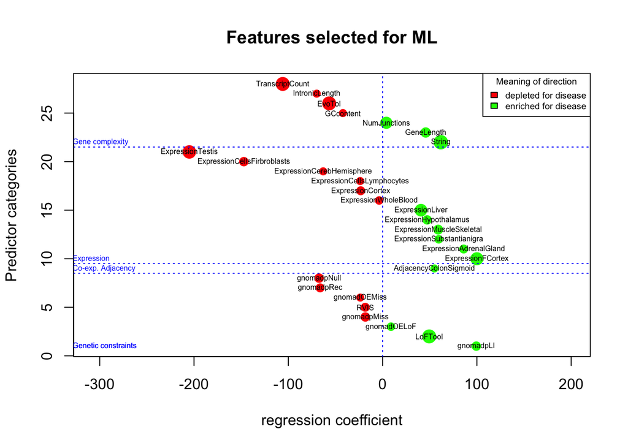

```r
G2PML::featureSelectionPlot(fspd,r=0.4)
```

that shows how the gene panel is enriched for green feature values (higher values of x axes indicate more importance). For example, these genes are particularly expressed in Frontal Cortex and the Substantia Nigra. But they are also particularly abundant for PPI entries in the String database. It is the other way around for the red features. Note that the plot somewaht reflects the number of times the variable was selected by Caret as relevant out of the number of repeats through the blob’s radius. Expression in Frontal Cortex is not only on of the features with strongest effect but also one of the most frequent within iterations. The same goes, on the opposite sense, for expression in testis and the number of transcripts at the genes.

# Learning a model

Let us suppose we want to develop a model for the PD genes. We incorporate the results of the feature selection through `fspd`, we will use the default algorithms in the tournament (CART, C5.0, SVMs, random forest, LDA, knn), the number of basic models in the ensemble will be as much as 20, the number of folds in the cross-validation of the ensemble, $k=5$ and the number of max trials without success before we stop growing the ensemble is also $5$ (note that a trial implies trying all the algorithms and all must fail improving the ensemble). As in the feature selection process, we use as controls the rest of the genome.

```r
mypanel="Parkinson_Disease_and_Complex_Parkinsonism"
mymodel = ensembleLearnKFold(panel=mypanel,genes=genes,fs=fspd,nboot=20,
                             auto=T,k=5,maxTrials=5,controls="allgenome")
```

And we get

```r
pdmodel = readRDS("~/Dropbox/KCL/workspace/G2PML/inst/g2pml/Parkinson_Disease_and_Complex_Parkinsonism.Apr2018.rds")
names(pdmodel$eval)
```

```
## [1] "hits"           "hitsperfold"    "allpredictions" "bestq"
## [5] "qfold"          "finalpreds"     "kappa"
```

And now we study the most relevant fields. If we want to get the most reliable gene predictions, we do

```r
print(pdmodel$eval$finalpreds)
```

```
##   [1] "ABCC8"    "ACACB"    "ACAN"     "ACLY"     "ACTB"     "ACTG1"
##   [7] "ACTN4"    "ACVR1"    "ADCY4"    "ADCY7"    "AGT"      "AKAP13"
##  [13] "AKT2"     "AMPD3"    "ANAPC5"   "ANK3"     "APC"      "APLP2"
##  [19] "APP"      "ARNT"     "ATF2"     "ATM"      "ATP2A2"   "ATP2A3"
##  [25] "ATP2B1"   "ATP2B2"   "ATXN3"    "BRCA1"    "CACNA1D"  "CACNA1H"
##  [31] "CACNB2"   "CACNB3"   "CALB1"    "CALD1"    "CALM1"    "CAMK2B"
##  [37] "CAPN1"    "CD36"     "CD44"     "CFTR"     "CHD3"     "CHD4"
##  [43] "CHD7"     "CHD9"     "CHEK2"    "CLASP2"   "CNTNAP2"  "COL11A1"
##  [49] "COL12A1"  "COL13A1"  "COL14A1"  "COL16A1"  "COL1A1"   "COL1A2"
##  [55] "COL21A1"  "COL27A1"  "COL4A2"   "COL5A1"   "COL6A3"   "COL7A1"
##  [61] "COL9A1"   "CPS1"     "CPSF7"    "CSK"      "CSNK1A1"  "CSNK1D"
##  [67] "CTBP2"    "CTNNA1"   "CTNND2"   "DAG1"     "DCTN2"    "DDX5"
##  [73] "DHCR7"    "DLG1"     "DLG2"     "DNM1"     "DNM1L"    "DNM2"
##  [79] "DNMT1"    "DPYSL2"   "DTNB"     "DYNC1I1"  "ECE1"     "EGFR"
##  [85] "EIF4G1"   "EP300"    "EPS15"    "ERBB3"    "ERC1"     "ERCC2"
```

[output cut: 37 more lines]

and we get 311 genes that, given the omics features of our gene panel, should be associated to monogenic forms of PD when data arrives for that. The Kappa statistic for the ensemble on the test data are

```r
pdmodel$eval$kappa
```

```
##     folds meankappa  maxkappa  minkappa
## 5.0000000 0.5268570 0.6581828 0.3847122
```

Which are pretty decent, given that Kappa values are in $[-1,1]$ and values over 0.5 are reasonably good.

# Annotating predictions

Predictions of this nature are difficult to assess computationally. It is true that we have estimates of the generalization power of the ML prediction models. However, we must note that for small gene panels with few genes, generalization capacity estimates (or error estimates) are difficult to obtain in a reasonable confidence interval. These estimates don’t offer a way of ranking the predictions as a first step before deciding which genes should be taken to the lab for experimental validation.

In this section we introduce some approaches incorporated into the G2PML package to work on that direction.

## PCA plots

Ways of visualizing results including a PCA like plot can be used. For example, we can see how genome, disease genes and predictions, arrange in a 1st 2 PCA axes-like plot as follows

```
## ALLGENOME mode: We have to remove 30 disease genes from the all genome controls
## We have to remove 52 genes RTF2 MTREX TUT7 RAB5IF PPP1R2C  because we don't know them
## Removing columns for attributes DPI and DSI and ESTcount and constitutiveexons
```

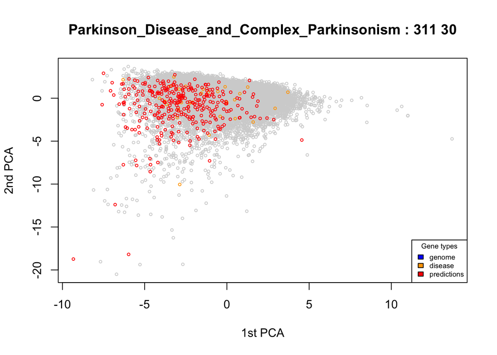

```r
G2PML::pcaPlot(fsdata=fspd,r=0.4,ensemble=pdmodel,bestPCAs = F)
```

But as a cautionary tale, separation between genome and disease genes will be subtle. We can look for PCAs that potentially correlate with disease status as follows

```
## ALLGENOME mode: We have to remove 30 disease genes from the all genome controls
## We have to remove 52 genes RTF2 MTREX TUT7 RAB5IF PPP1R2C  because we don't know them
## Removing columns for attributes DPI and DSI and ESTcount and constitutiveexons
```

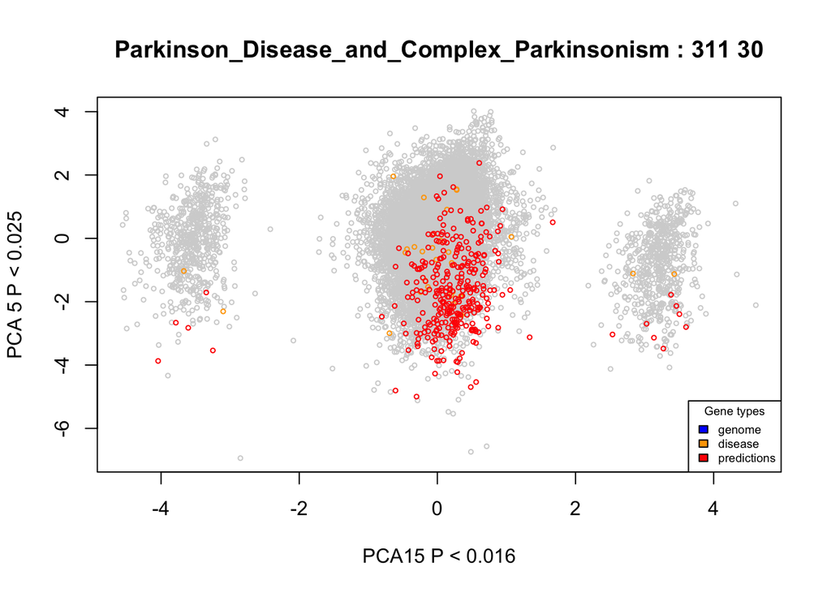

```r
G2PML::pcaPlot(fsdata=fspd,r=0.4,ensemble=pdmodel,bestPCAs = T)
```

And the separation will be somewhat better. In this example we see we are predicting 311 new disease genes and we used 30 as disease genes from the initial panel.

## Automated literature search

Amelie is a TGTBT (Too Good To Be True) kind of tool. Have a read at https://amelie.stanford.edu/. The tool needs a list of genes and a list of phenotype terms from the HPO (Human Phenotype Ontology) database that it associates to the whole set of genes. You can select the phenotype term from here http://compbio.charite.de/hpoweb/showterm?id=HP:0000118#id=HP_0000118.

What Amelie does is an association for each gene of a list of papers about mendelian diseases, related to the phenotype and the gene. Each gene-paper association comes with a score from 0 to 100. Highest values show highest confidence of the Mendelian association of the gene to the phenotype within the paper. Amelie will return the papers in the form of PUBMED ids. G2PML offers facilites to use Amelie through its Web API and it is as simple as follows if we continue with the example of PD and the ensemble we got already.

```r
library(RCurl)
library(RJSONIO)
pdamelie = annotateWithAmelie(ensemble=pdmodel)
```

```
## Working with Parkinson_Disease_and_Complex_Parkinsonism
## Working with HP:0001300
## Calling Amelie now
## Done!
##      [,1]              [,2]
## [1,] "100"             "10495048"
## [2,] "10.962542514765" "12898587"
## [3,] "10.962542514765" "20637261"
## [4,] "10.962542514765" "9350853"
## [5,] "10.962542514765" "11496365"
##      [,1]               [,2]
## [1,] "100"              "25799905"
## [2,] "100"              "24874546"
## [3,] "37.8435835451919" "25239001"
## [4,] "37.8435835451919" "27270488"
```

[output cut: 1254 more lines]

```r
cat("We got annotations for",
    100*length(unique(pdamelie$gene[!is.na(pdamelie$confidence)]))/length(pdmodel$eval$finalpreds),
    "% of the genes")
```

```
## We got annotations for 75.24116 % of the genes
```

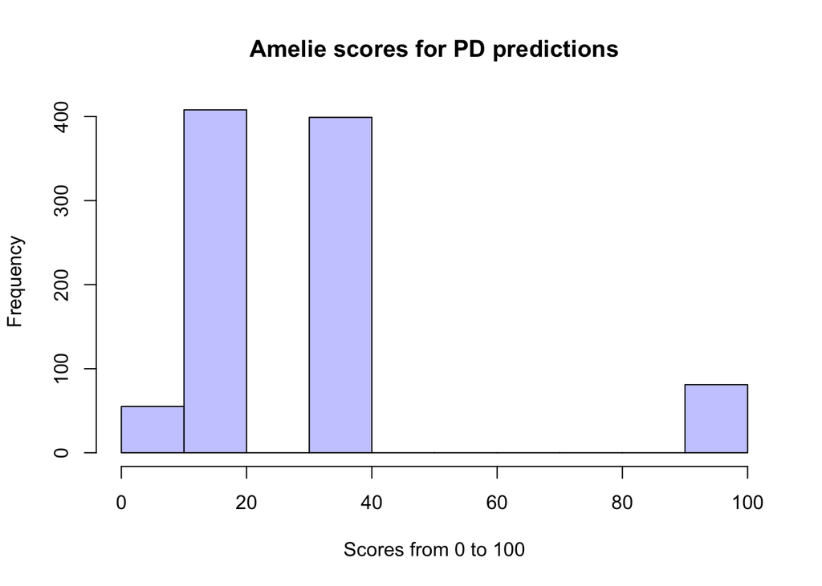

```r
pdamelie = na.omit(pdamelie)
hist(as.numeric(pdamelie$confidence),main="Amelie scores for PD predictions",xlab="Scores from 0 to 100",col=rgb(0,0,1,1/4))
```

And if we focus on genes with score 100, we get papers like (only the 1st 10 shown)

```r
mask = pdamelie$confidence == 100
pdamelie[mask,c("gene","title","journal")][1:10,]
```

```
##     gene
## 1   LRP1
## 6  SCN8A
## 7  SCN8A
## 11 SCN2A
## 16 DNMT1
## 21 KIF1A
## 26 GRIN1
## 27 GRIN1
## 31 SCN1A
## 32 SCN1A
##                                                                                                                       title
## 1                    Low-density lipoprotein receptor-related protein (LRP) gene 766T polymorphism and Parkinson's disease.
## 6                        Early-onset movement disorder and epileptic encephalopathy due to de novo dominant SCN8A mutation.
## 7     A novel de novo mutation of SCN8A (Nav1.6) with enhanced channel activation in a child with epileptic encephalopathy.
```

[output cut: 18 more lines]

This tool can be very useful if we want a starting point from where to start looking for papers that back up our predictions.

## Enrichment of functional terms

And of course we can annotate our gene predictions with tools as the gProfileR R package as follows

```r
enrpd = gProfileR::gprofiler(query=pdmodel$eval$finalpreds,src_filter=c("GO","KEGG","REAC","HP","HPA","OMIM"))
```

So we can get a hint of what we find with wordcloud, from left to right, top to bottom, the cellular component in the GO ontology, molecular function from the same ontology, Human phenotype terms and REACTOME pathways.

```r
jpeg("pdwordcloud.png",width=600,height=600)
par(mfrow=c(2,2))
wordcloud::wordcloud(enrpd$term.name[enrpd$domain == "CC"],random.order=F,min.freq=1,max.words=40)
wordcloud::wordcloud(enrpd$term.name[enrpd$domain == "MF"],random.order=F,min.freq=1,max.words=40)
wordcloud::wordcloud(enrpd$term.name[enrpd$domain == "hp"],random.order=F,min.freq=1,max.words=40)
wordcloud::wordcloud(enrpd$term.name[enrpd$domain == "rea"],random.order=F,min.freq=1,max.words=40)
dev.off()
```

```r
par(mfrow=c(1,1))
```

And we get

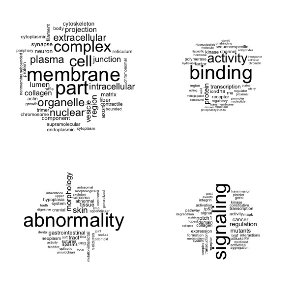

Word clouds for CC, MM, HP and REACTOME